# Sutter’s Mill

# Setting (Short Version)

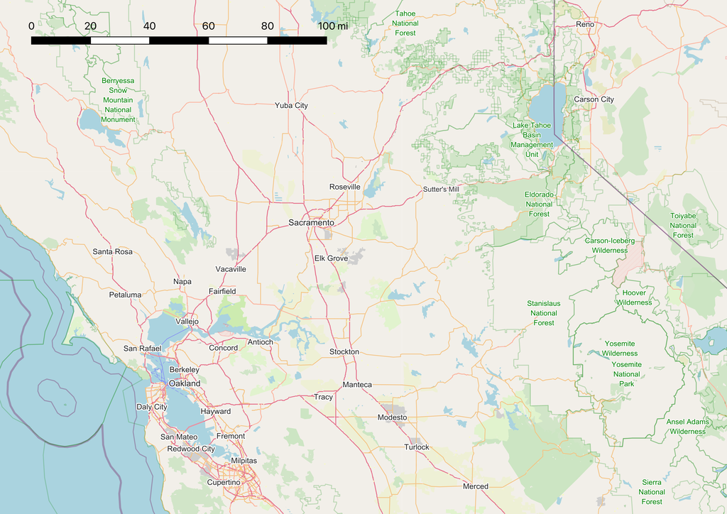

Map of Northern California, showing Sutter’s Mill in relation to Sacramento, Lake Tahoe, and the Bay Area

Sutter’s Mill is a geographic mashup of Placerville (my hometown); the smaller community of Coloma, located about 30 miles north and the actual site of Sutter’s mill (which was actually the place where gold was discovered in 1848); and Merced and UC Merced (where I currently live and teach). This personal setting is a way for me to tell stories about the communities in which I grew up and live today. Adventures in Sutter’s Mill may include themes such as racism (including historical genocide and dispossession), class conflict (including stereotypes of rural people), rural-urban politics, and suburban sprawl.

Monster of the Week [MotW] is an action-supernatural game. On the supernatural side, much of the lore behind events in Sutter’s Mill will be inspired by the Cthulhu mythos, especially the [Delta Green setting](https://en.wikipedia.org/wiki/Delta_Green) created by Adam Scott Glancy, Dennis Detwiller, and John Scott Tynes. Delta Green was originally written in the early ’90s, and bears significant resemblance to *The X-Files* (federal agents trying to contain supernatural phenomena; greys and UFOs; post-Cold War intrigue). Some of these specific elements might show up in Sutter’s Mill adventures; but since the PCs are college students, not federal law enforcement, they’ll get a very different perspective on things.

# The PCs

The PCs are all connected to Sutter’s Mill State — typically students, but occasionally a PC can be on the faculty or staff. PCs are mostly mundane, and connecting to the unnatural almost always has undesirable side effects (see the section Connecting with the Unnatural). A PC might have prior experience with the unnatural, but limited genuine knowledge and ability to manipulate it. One implication here is that some of the MotW playbooks don’t work for PCs in this setting. There’s a list of available playbooks below. If you’re having trouble translating a playbook to a college student, check out the advice on “Kids as Characters,” ToM 86.

MotW assumes that the PCs are already part of a monster-hunting team. You might be part of a supernatural/paranormal/science fiction-themed club; or work together in the lab of a faculty member (who might be one of the PCs). Or maybe you’re just a group of friends who are into Wicca. Your team doesn’t need to lean hard on the “monster hunting” idea, so long as the characters are motivated to investigate (and stop) supernatural badness.

# Homebrews, optional rules, and dial settings

## Connecting with the Unnatural

Detailed separately

## Available Playbooks

- Crooked
- Expert
- Flake
- Gumshoe
- Initiate
- Mundane
- Professional (check with Keeper)
- Searcher
- Snoop
- Wronged
- Spooky OR Hex (only one of these per group)

Note for the Spooky and Hex: If you plan to exploit the unnatural (use magic) to attack regularly, take Big Whammy (Spooky) or write a damaging rote (Hex). The backlash from exploiting the unnatural is nasty by design, but these moves are exempt.

## Rules for one-shots

- PCs have 2 Luck points but take an Improvement at character creation. (MotW 292)

## Rules for campaigns

- Moves that apply to “the current mystery” generally apply to the current session

## More flexible investigations

When you **investigate a mystery** with your particular techniques and skills, roll +Sharp:

- On a 10 or higher, ask the Keeper two general questions or one specific question. Based on how you are investigating, they will tell you honestly and with good detail what you discover.
- On a 7 to 9, ask the Keeper one general question. Based on how you are investigating, they will tell you honestly and with reasonable detail what you discover.
- On a miss, ask the Keeper one general question. They may answer it as they wish. Regardless of the question and answer, something bad happens.

When you advance this move, add this extra result:

- On a 12 or higher, as 10 or higher but you may ask one additional question—specific or general, your choice.

Many hunters have moves that grant special questions to ask instead of the usual list. To ensure these moves are still valuable, they now grant one of those special questions in addition to the questions granted by your investigate a mystery move result. (ToM 29)

# Setting (Long Version)

*This is the entry “Sutter’s Mill, California” in the *Encyclopedia of the West*, published by Big Trees Press in 1992. Reflecting mainstream views at the time, this entry neglects the history of indigenous people and Asian Americans in the Sutter’s Mill area. In the second half of the nineteenth century, American settlers — including John Sutter — used indigenous peoples for slave labor and engaged in some of the most vicious genocidal campaigns in US history. The Gold Rush and railroad construction attracted a significant number of Chinese immigrants, who were later violently forced out of many parts of the state after the passage of the Chinese Exclusion Act in 1882. Many Japanese immigrants also came to the area in the nineteenth and early twentieth centuries and became successful, established farmers. The interment of Japanese Americans during World War 2 was partly done in order to transfer farmland from Japanese American smallholders to white-controlled agribusiness concerns (https://www.washingtonpost.com/archive/opinions/1992/02/02/bitter-harvest/c8389b23-884d-43bd-ad34-bf7b11077135/).*

Professor Amy Bonaventure, introductory note for assigned reading for History 104, “History of California since 1848,” Fall 2018, CSU Sutter’s Mill

Sutter’s Mill is the county seat of El Dorado County, California. The city’s population was 34,738 residents in the 1990 census, more than double the population of 14,003 residents in the 1980 census. Another 11,662 residents lived in the unincorporated zip code for Sutter’s Mill State, and 5,221 residents lived in other unincorporated areas immediately outside of the city borders.

## History

On January 24, 1848, James Marshall, a foreman at the mill, discovered gold, launching the California Gold Rush. By April 1849, Sutter’s Mill had become an sprawling tent city of nearly 5,000, making it briefly the largest settlement in the California territory.

As mining operations expanded throughout the Sierra Nevada mountains, Sutter’s Mill remained the regional hub. The American River provided access to Sacramento — as the settlement around Sutter’s Fort was now known — which in turn provided access to the ocean ports at San Francisco and Oakland. Sutter’s Mill was incorporated in 1854.

Several monuments to the Gold Rush origins of Sutter’s Mill still remain. The historic Main Street includes several nineteenth century buildings, a few of which have open mines extending from their back rooms into the hillside. The Marshall Gold Discovery State Historic Park includes the original mill, relocated away from the river in the 1970s to protect from flooding.

## Geography

Sutter’s Mill is located in the Sierra Nevada foothills, east of Sacramento and west of South Lake Tahoe. U.S. Route 50 crosses State Route 49 just west of Sutter’s Mill’s historic main street. Sutter’s Mill is nestled in a relatively wide valley formed by the American River. For several miles in either direction, the river flows through narrow canyons with steep sides. The valley floor is about 1,900 feet above sea level, but nearby unincorporated areas can be as high as 4,000 feet, and high passes through the Sierra Nevada to the east can approach 10,000 feet.

## Climate

Sutter’s Mill has cool, wet winters and hot, dry summers, creating a typically Californian Mediterranean climate. Average January temperatures are a maximum of 52ºF and a minimum of 32ºF. Average July temperatures are a maximum of 93ºF and a minium of 58ºF. Average annual rainfall is 38”, which is spread unevenly throughout the year. Typically there is no measurable rainfall between May and October. Although snowfall is rare within city limits, surrounding areas experience regular snow in the winter, and heavy amounts often fall in the mountains to the east.

## Demographics

Sutter’s Mill experienced rapid population growth between 1980 and 1990. The city’s population was 34,738 residents in the 1990 census, more than double the population of 14,003 residents in the 1980 census. This change was due to a combination of factors, including the opening of California State University, Sutter’s Mill, and the extension of the Sacramento suburbs into El Dorado County.

## Economy

The Gold Rush was relatively short-lived. By 1855 manual methods such as gold panning had given way to hydraulic and hard rock mining mining. Due to the challenging terrain of the Sierra Nevada mountains, it was difficult for these technologically-intensive methods to spread widely, and by the 1890s mining had become a small part of the regional economy.

For the next century, the economy of the area was primarily based on agriculture. Apples, pears, and grapes were major fruit crops, and cattle were raised for both dairy and meat on the rockier pastures. Pleasant Valley, about ten miles beyond Sutter’s Mill on U.S. Route 50, has an annual harvest festival each fall, attracting tourists from as far away as the San Francisco Bay Area.

Forestry, electrical generation, and outdoor recreation are also important industries in the higher mountains to the east of Sutter’s Mill. Much of the eastern half of El Dorado County is public land incorporated in the El Dorado National Forest. The Georgia-Pacific Paper Company regularly obtains permits to log tracks of the El Dorado National Forest. Several utilities based in the Central Valley and San Francisco Bay Area operate dams and reservoirs for water storage, hydroelectric power, and recreation.

Starting in the 1970s, the aerospace industry opened new research facilities in the eastern parts of Sacramento County. A major expansion of U.S. Route 50 meant that Sutter’s Mill was less than hour away from these white collar jobs. A number of professional families moved to Sutter’s Mill for its attractive climate and easy country lifestyle. The opening of the new California State University campus further attracted white collar workers to the rural community. The area’s first planned housing development, Golden Oaks Estates, opened just outside of the city limits in 1985. Golden Oaks Estates features 2-acre lots, trails for horseback riding, and a small lake for the private use of residents.

Sutter’s Mill is home to the Gold Country Star newspaper, which has been in print continuously since 1852, and Sutter Hospital.

## Transportation

While the American River was originally navigable between Sutter’s Mill and Sacramento, a series of dams means that today the river is mostly used for white-water rafting in the nearby canyons.

Two highways run through Sutter’s Mill. U.S. Route 50 runs east-west, connecting Sacramento to Lake Tahoe and beyond. State Route 49, commemorating the ’49ers of the Gold Rush, runs north-south, connecting several historic towns and cities in the Sierra foothills.

By car, using modern highways, Sutter’s Mill is approximately 50 miles from Sacramento to the west; a further 70 miles from San Francisco; 50 miles from Lake Tahoe to the east; and a further 50 miles from Reno, Nevada. Between December and February, travel to and from Lake Tahoe can be severely impacted by heavy snowfall.

Sutter’s Mill Airfield is located in the hills to the north of the city. It is primarily used for firefighting activities in the nearby forests but is available for use by private aircraft.

## Education

The Sutter’s Mill area has three high schools. Sutter’s Mill High School (est. 1928) serves residents of the city proper. Greenstone High School (est. 1963) is located ten miles to the east, and primarily serves students in the more rural, unincorporated parts of the area. The newest high school, Golden Oaks High School (est. 1990) primarily serves residents of Golden Oaks Estates and other planned communities immediately to the west of the city.

California State University, Sutter’s Mill, known informally as “Sutter State,” is a public university in Sutter’s Mill. The university matriculated its first students in 1983.